# Week 4

Edneide Ramalho

24 Setembro, 2021

# 1 Data

- Train data set

```r
library(readr)
X_train <- read_table2("Week 4/UCI HAR Dataset/train/X_train.txt",
    col_names = FALSE)
dim(X_train)
```

```
## [1] 7352  561
```

- Training labels:

1 WALKING

2 WALKING_UPSTAIRS

3 WALKING_DOWNSTAIRS

4 SITTING

5 STANDING

6 LAYING

```r
library(readr)
y_train <- read_csv("Week 4/UCI HAR Dataset/train/y_train.txt",
    col_names = FALSE)
```

- Mudando o nome da variável:

```r
names(y_train) <- "activity"
```

```r
table(y_train$activity)
```

```
##
##    1    2    3    4    5    6
## 1226 1073  986 1286 1374 1407
```

- Adding the activity name to `y_train`:

```r
library(readr)
activity_labels <- read_table2("Week 4/UCI HAR Dataset/activity_labels.txt",
    col_names = FALSE)
names(activity_labels)
```

```
## [1] "X1" "X2"
```

- Join `activity_labels` to `y_train`:

```r
library(tidyverse)
y_train <- y_train %>%
  left_join(activity_labels, by = c("activity" = "X1"))
glimpse(y_train)
```

```
## Rows: 7,352
## Columns: 2
## $ activity <dbl> 5, 5, 5, 5, 5, 5, 5, 5, 5, 5, 5, 5, 5, 5, 5, 5, 5, 5, 5, 5, 5…
## $ X2       <chr> "STANDING", "STANDING", "STANDING", "STANDING", "STANDING", "…
```

```r
names(y_train)[2]  <- "activity_name"
```

```r
glimpse(y_train)
```

```
## Rows: 7,352
## Columns: 2
## $ activity      <dbl> 5, 5, 5, 5, 5, 5, 5, 5, 5, 5, 5, 5, 5, 5, 5, 5, 5, 5, 5,…
## $ activity_name <chr> "STANDING", "STANDING", "STANDING", "STANDING", "STANDIN…
```

- Importing features:

  ```r
  library(readr)
  features <- read_table2("Week 4/UCI HAR Dataset/features.txt",
      col_names = FALSE)
  names(features)[2] <- "features"
  ```

- Replacing features names to the `X_train` dataset and adding the activity label.

```r
names(X_train) <- features$features
```

```r
samsung_data <- cbind(y_train, X_train)
```

- We’d like to separate the activities depending on the values we have for the features.

```r
table(samsung_data$activity_name)
```

```
##
##             LAYING            SITTING           STANDING            WALKING
##               1407               1286               1374               1226
## WALKING_DOWNSTAIRS   WALKING_UPSTAIRS
##                986               1073
```

- Adding the subject name:

```r
subject_train <- read_csv("Week 4/UCI HAR Dataset/train/subject_train.txt", col_names = FALSE)
names(subject_train) <- "subject"
```

```r
samsung_data <- cbind(subject_train, samsung_data)
names(samsung_data)[1:6]
```

```
## [1] "subject"           "activity"          "activity_name"
## [4] "tBodyAcc-mean()-X" "tBodyAcc-mean()-Y" "tBodyAcc-mean()-Z"
```

# 2 Plotting average accelaration for the first subject

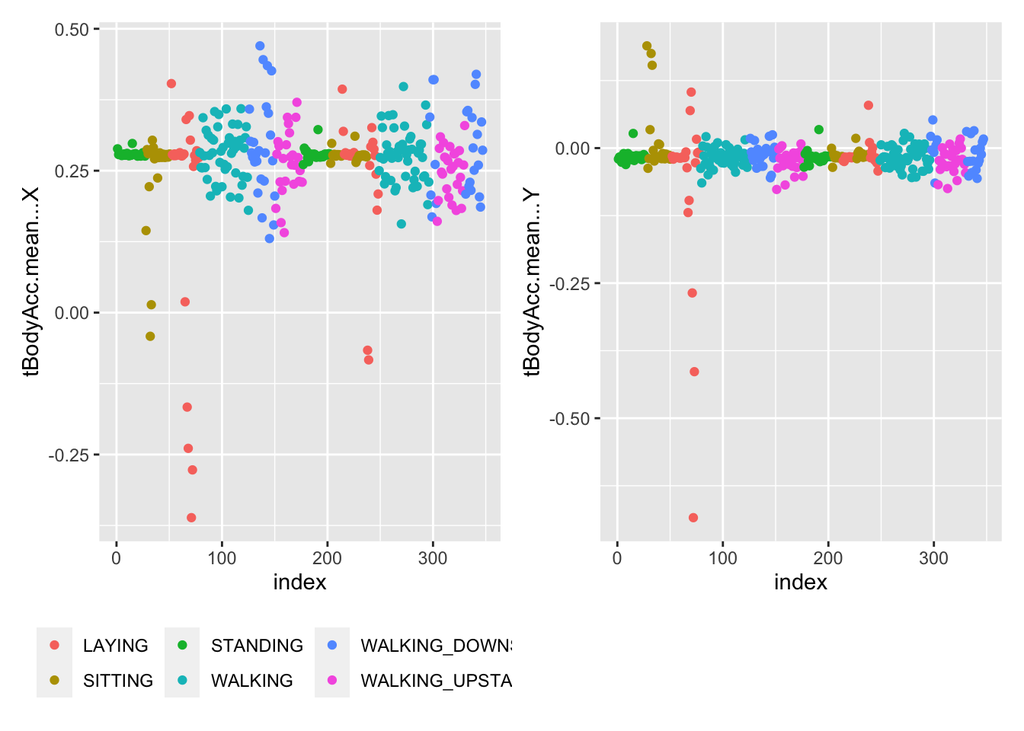

```r
library(patchwork)
library(ggplot2)
library(magrittr)
library(tidyverse)

df1 <- samsung_data %>%
  filter(subject == 1)
df1$index <- 1:dim(df1)[1]

plot1 <- ggplot(df1, aes(x = index, y = tBodyAcc.mean...X, color = activity_name)) +
  geom_point() +
  theme(legend.position = "bottom",
        legend.title = element_blank())

plot2 <- ggplot(df1, aes(x = index, y = tBodyAcc.mean...Y, color = activity_name)) +
  geom_point() +
  theme(legend.position = "none",
        legend.title = element_blank())

plot1 + plot2
```

# 3 Clustering based just on average acceleration

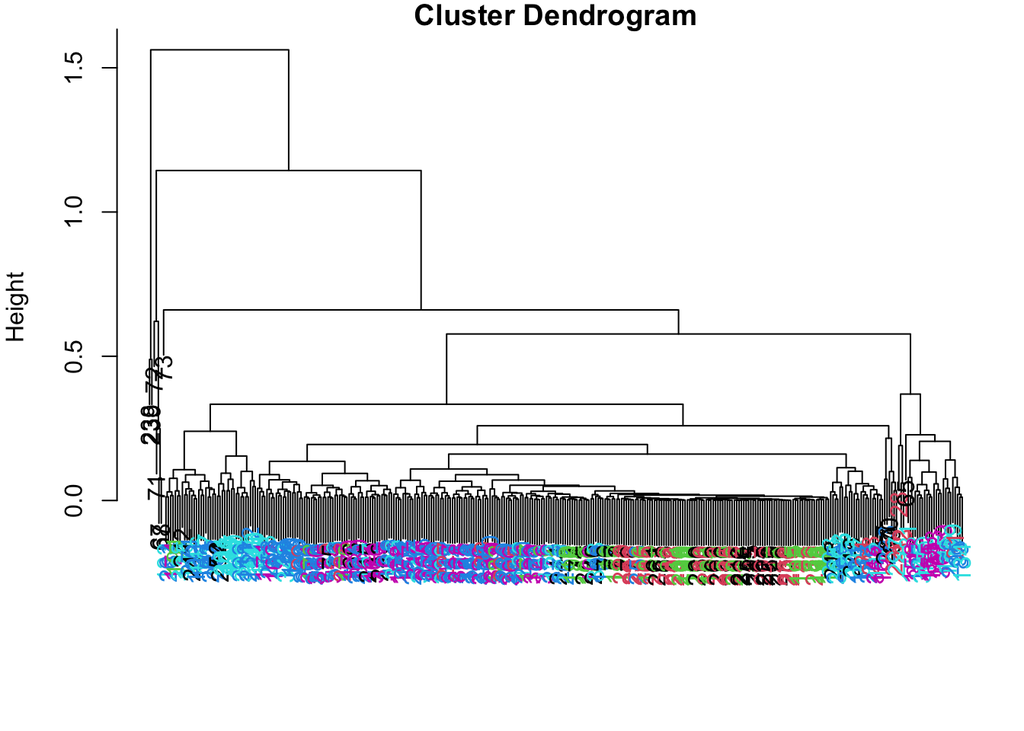

```r
# library(devtools) # get from CRAN with install.packages("devtools")
# install_github("ririzarr/rafalib")

library(rafalib)
distance_matrix <- dist(sub1[, 4:6])
hclustering <- hclust(distance_matrix)
par(mfrow = c(1, 1), mar = c(5, 4, 1, 1))
myplclust(hclustering, lab.col = unclass(sub1$activity_name))
```

The colors for specific activities are still messed up. We cannot see a clear pattern on the dendrogram.

# 4 Plotting max acceleration for the first subject

```r
names(sub1)[1:20]
```

```
##  [1] "subject"             "activity"            "activity_name"
##  [4] "tBodyAcc.mean...X"   "tBodyAcc.mean...Y"   "tBodyAcc.mean...Z"
##  [7] "tBodyAcc.std...X"    "tBodyAcc.std...Y"    "tBodyAcc.std...Z"
## [10] "tBodyAcc.mad...X"    "tBodyAcc.mad...Y"    "tBodyAcc.mad...Z"
## [13] "tBodyAcc.max...X"    "tBodyAcc.max...Y"    "tBodyAcc.max...Z"
## [16] "tBodyAcc.min...X"    "tBodyAcc.min...Y"    "tBodyAcc.min...Z"
## [19] "tBodyAcc.sma.."      "tBodyAcc.energy...X"
```

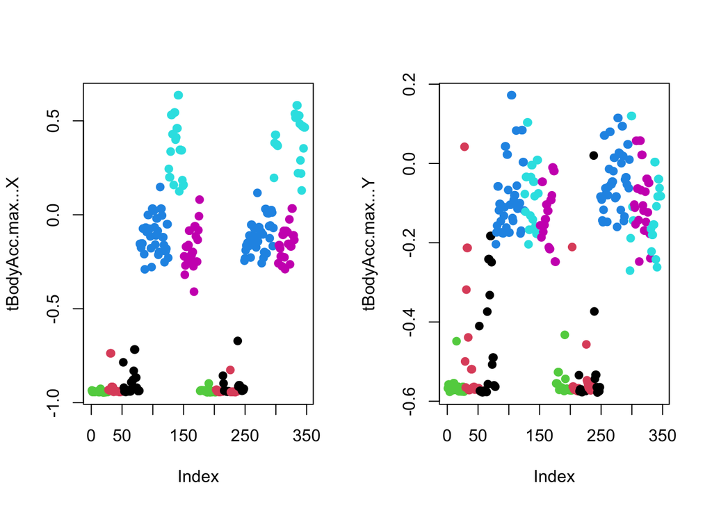

```r
par(mfrow = c(1, 2))
plot(sub1[, 13], pch = 19,
     col = sub1$activity_name, ylab = names(sub1)[13])
plot(sub1[, 14], pch = 19,
     col = sub1$activity_name, ylab = names(sub1)[14])
```

The maximum accelaration seems to separate more clearly the moving and not moving activities.

Now, let’s cluster based on the maximum accelaration

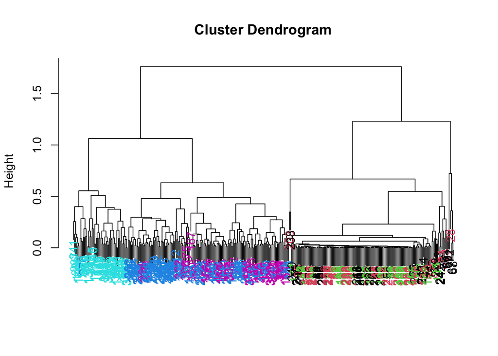

```r
distance_matrix2 <- dist(sub1[, 13:15])
hclustering2 <- hclust(distance_matrix2)
par(mfrow = c(1, 1))
myplclust(hclustering2,
          lab.col = unclass(sub1$activity_name))
```

Now we can see on the left-hand side walking activities and in the right-hand side we can see the not-moving activities.

Maximum accelaration seem to cluster well moving from not-moving activities. But inside of these two big clusters, it’s difficult to see the division of the activities inside them.